# Trends of international student admission in NCKU

Brian

6/24/2021

We analyzed data of ‘admitted’ international students in 2021(n=468) to discover trends in higher education in Taiwan. (work in progress)

**Descriptive statistics**

First of all, descriptive statistics by nationality, college, department, and degree are presented.

By nationality

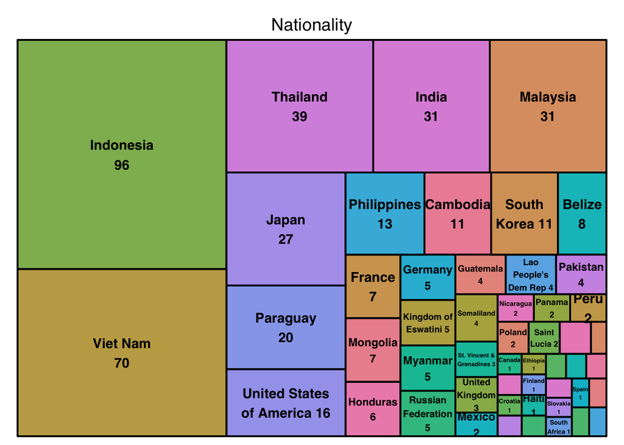

| Nationality | count | % |
| --- | --- | --- |
| Indonesia | 96 | 20.5 |
| Viet Nam | 70 | 15.0 |
| Thailand | 39 | 8.3 |
| India | 31 | 6.6 |
| Malaysia | 31 | 6.6 |
| Japan | 27 | 5.8 |
| Paraguay | 20 | 4.3 |
| United States of America | 16 | 3.4 |
| Philippines | 13 | 2.8 |
| Cambodia | 11 | 2.4 |
| South Korea | 11 | 2.4 |
| Belize | 8 | 1.7 |
| France | 7 | 1.5 |
| Mongolia | 7 | 1.5 |
| Honduras | 6 | 1.3 |
| Germany | 5 | 1.1 |
| Kingdom of Eswatini | 5 | 1.1 |
| Myanmar | 5 | 1.1 |
| Russian Federation | 5 | 1.1 |
| Guatemala | 4 | 0.9 |
| Lao People’s Dem Rep | 4 | 0.9 |
| Pakistan | 4 | 0.9 |
| Somaliland | 4 | 0.9 |
| St. Vincent & Grenadines | 3 | 0.6 |
| United Kingdom | 3 | 0.6 |
| Mexico | 2 | 0.4 |
| Nicaragua | 2 | 0.4 |
| Panama | 2 | 0.4 |
| Peru | 2 | 0.4 |
| Poland | 2 | 0.4 |
| Saint Lucia | 2 | 0.4 |
| Switzerland | 2 | 0.4 |
| Austria | 1 | 0.2 |
| Canada | 1 | 0.2 |
| Colombia | 1 | 0.2 |
| Croatia | 1 | 0.2 |
| El Salvador | 1 | 0.2 |
| Ethiopia | 1 | 0.2 |
| Finland | 1 | 0.2 |
| Haiti | 1 | 0.2 |
| Hungary | 1 | 0.2 |
| Norway | 1 | 0.2 |
| Portugal | 1 | 0.2 |
| Republic of Somaliland | 1 | 0.2 |
| Saint Kitts and Nevis | 1 | 0.2 |
| Slovakia | 1 | 0.2 |
| South Africa | 1 | 0.2 |
| Spain | 1 | 0.2 |
| Sri Lanka | 1 | 0.2 |
| Tanzania | 1 | 0.2 |
| Zimbabwe | 1 | 0.2 |

By college

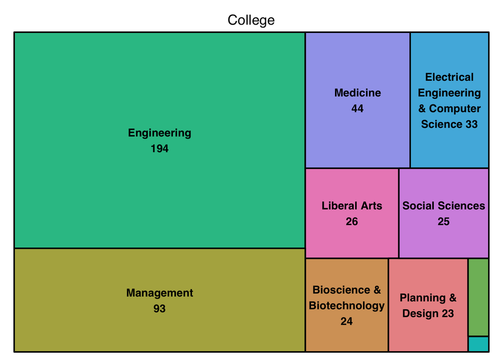

| College | count | % |
| --- | --- | --- |
| Engineering | 194 | 41.5 |
| Management | 93 | 19.9 |
| Medicine | 44 | 9.4 |
| Electrical Engineering & Computer Science | 33 | 7.1 |
| Liberal Arts | 26 | 5.6 |
| Social Sciences | 25 | 5.3 |
| Bioscience & Biotechnology | 24 | 5.1 |
| Planning & Design | 23 | 4.9 |
| Sciences | 5 | 1.1 |
| Miin Wu School of Computing | 1 | 0.2 |

By department

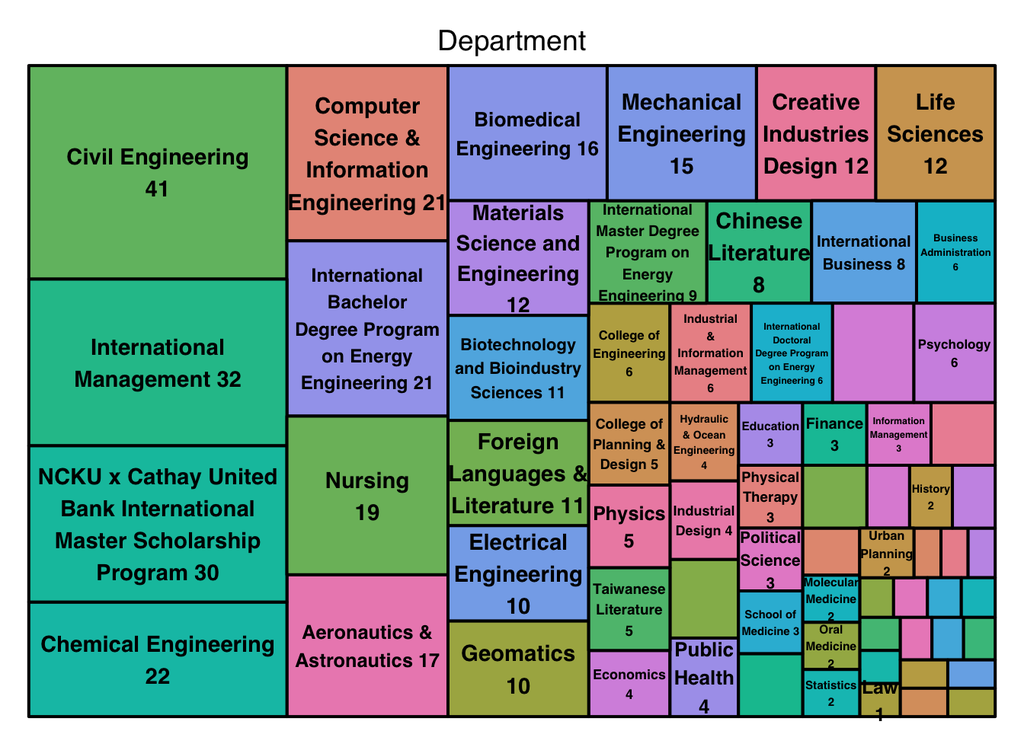

| Department | count | % |
| --- | --- | --- |
| Civil Engineering | 41 | 8.8 |
| International Management | 32 | 6.8 |
| NCKU x Cathay United Bank International Master Scholarship Program | 30 | 6.4 |
| Chemical Engineering | 22 | 4.7 |
| Computer Science & Information Engineering | 21 | 4.5 |
| International Bachelor Degree Program on Energy Engineering | 21 | 4.5 |
| Nursing | 19 | 4.1 |
| Aeronautics & Astronautics | 17 | 3.6 |
| Biomedical Engineering | 16 | 3.4 |
| Mechanical Engineering | 15 | 3.2 |
| Creative Industries Design | 12 | 2.6 |
| Life Sciences | 12 | 2.6 |
| Materials Science and Engineering | 12 | 2.6 |
| Biotechnology and Bioindustry Sciences | 11 | 2.4 |
| Foreign Languages & Literature | 11 | 2.4 |
| Electrical Engineering | 10 | 2.1 |
| Geomatics | 10 | 2.1 |
| International Master Degree Program on Energy Engineering | 9 | 1.9 |
| Chinese Literature | 8 | 1.7 |
| International Business | 8 | 1.7 |
| Business Administration | 6 | 1.3 |
| College of Engineering | 6 | 1.3 |
| Industrial & Information Management | 6 | 1.3 |
| International Doctoral Degree Program on Energy Engineering | 6 | 1.3 |
| Master(PhD) Program of Political Economy, Political Science | 6 | 1.3 |
| Psychology | 6 | 1.3 |
| College of Planning & Design | 5 | 1.1 |
| Physics | 5 | 1.1 |
| Taiwanese Literature | 5 | 1.1 |
| Economics | 4 | 0.9 |
| Hydraulic & Ocean Engineering | 4 | 0.9 |
| Industrial Design | 4 | 0.9 |
| International Master Program on Natural Hazards Mitigation and Management | 4 | 0.9 |
| Public Health | 4 | 0.9 |
| Education | 3 | 0.6 |
| Finance | 3 | 0.6 |
| Information Management | 3 | 0.6 |
| Master of The International Institute of Medical Device Innovation (MDI) | 3 | 0.6 |
| Physical Therapy | 3 | 0.6 |
| Political Science | 3 | 0.6 |
| School of Medicine | 3 | 0.6 |
| Systems & Naval Mechatronic Engineering | 3 | 0.6 |
| The International Curriculum for Advanced Materials Program (iCAMP) | 3 | 0.6 |
| Basic Medical Sciences | 2 | 0.4 |
| History | 2 | 0.4 |
| Inst.of Clinical Pharmacy and Pharmaceutical Sciences | 2 | 0.4 |
| Master Degree Program on Artificial Intelligence | 2 | 0.4 |
| Molecular Medicine | 2 | 0.4 |
| Oral Medicine | 2 | 0.4 |
| Statistics | 2 | 0.4 |
| Urban Planning | 2 | 0.4 |
| Behavioral Medicine | 1 | 0.2 |
| Accountancy | 1 | 0.2 |
| Biochemistry & Molecular Biology | 1 | 0.2 |
| Clinical Medicine | 1 | 0.2 |
| Data Science | 1 | 0.2 |
| Engineering Science | 1 | 0.2 |
| Environmental and Occupational Health | 1 | 0.2 |
| Food Safety / Hygiene and Risk Management | 1 | 0.2 |
| International Doctoral Program in Principles and Implications of Mind Sciences | 1 | 0.2 |
| Law | 1 | 0.2 |
| Master Program on AI Robotics | 1 | 0.2 |
| Medical Laboratory Science and Biotechnology | 1 | 0.2 |
| NCKU-AS Graduate Program in Translational Agricultural Sciences | 1 | 0.2 |
| Pharmacology | 1 | 0.2 |
| PhD Program of Political Economy, Political Science | 1 | 0.2 |
| Resources Engineering | 1 | 0.2 |
| Transportation & Communication Management Science | 1 | 0.2 |

By degree

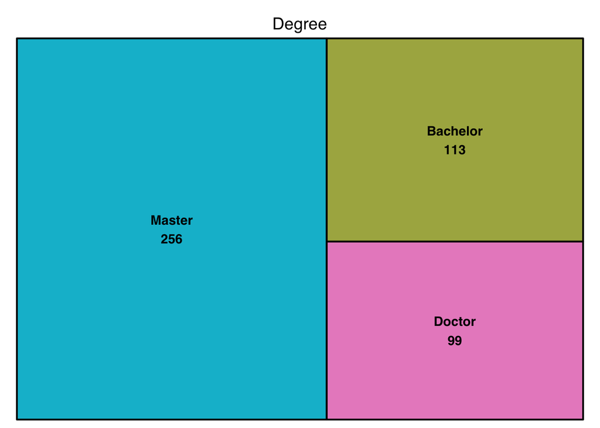

| Degree | count | % |
| --- | --- | --- |
| Master | 256 | 54.7 |
| Bachelor | 113 | 24.1 |
| Doctor | 99 | 21.2 |

**Interrelationship analysis**

The results of multi-variate analysis are presented here.

- Nationality and college
- Nationality and department
- Nationality and degree
- Department and degree
- Degree, nationality, and department
- Degree, nationality, and college

Nationality and college

The height of rectangular indicates the number of students. The width of the line indicates the number of students between connected rectangular

[interactive chart not shown]

Nationality and department

[interactive chart not shown]

Nationality and degree

[interactive chart not shown]

Department and degree

[interactive chart not shown]

Degree, nationality, and department

[interactive chart not shown]

Degree, nationality, college

[interactive chart not shown]

Go to [comparison](https://briankimstudio.github.io/New_student/)

*For full analysis results, refer to

- NCHU國立中興大學
- FCU逢甲大學
- NCKU國立成功大學
- NCTU國立陽明交通大學
- NTHU國立清華大學
- NCCU國立政治大學

Comparison

- NCTU國立陽明交通大學,NTHU國立清華大學